# Analysis 2 - Predicting Seedling Growth using GLS

```r
ggplot(pred)+
  geom_point(aes(y=Grth,x=Ht.cm,col=pred$Ht1, shape=pred$Fire))+
  scale_color_gradient(low="blue",high="red")+
  labs(title = "Measured values")
```

[output not shown]

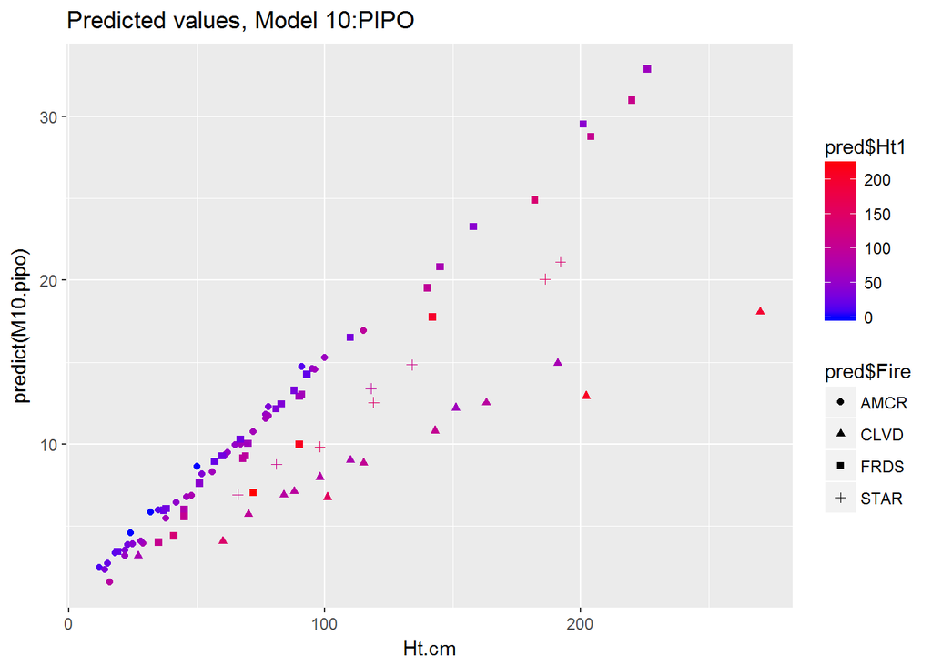

```r
pred <- as.data.frame(predict(M10.pipo))
pred$Cov <- dfPIPO$Cov1.2
pred$Ht1 <- dfPIPO$Ht1
pred$Ht.cm <- dfPIPO$Ht.cm
pred$Fire <- dfPIPO$Fire
pred$Grth <- dfPIPO$LastYearGrth.cm
pred$ShrG1<- dfPIPO$ShrG1
ggplot(pred)+
  geom_point(aes(y=predict(M10.pipo),x=Ht.cm,col=pred$Ht1, shape=pred$Fire))+
  scale_color_gradient(low="blue",high="red")+
  labs(title = "Predicted values, Model 10:PIPO")
```

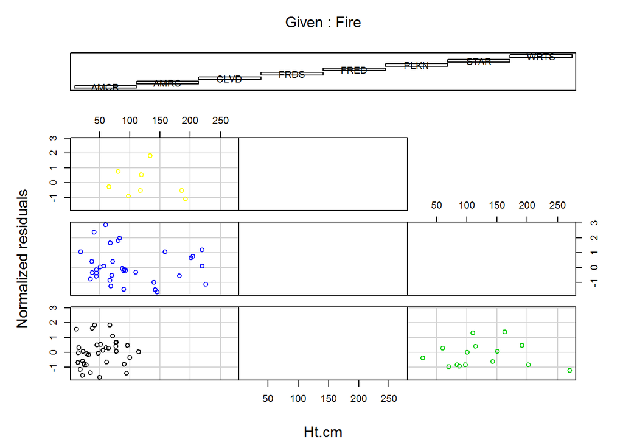

```r
E10.pipo <- resid(M10.pipo, type="normalized")
coplot(E10.pipo ~ Ht.cm | Fire, data=dfPIPO, ylab="Normalized residuals", col=dfPIPO$Fire)
```

- Are the different slopes caused by different shrub heights or covers in different patches (ie covariance between fire and shrub heights or covers or shrub species?)

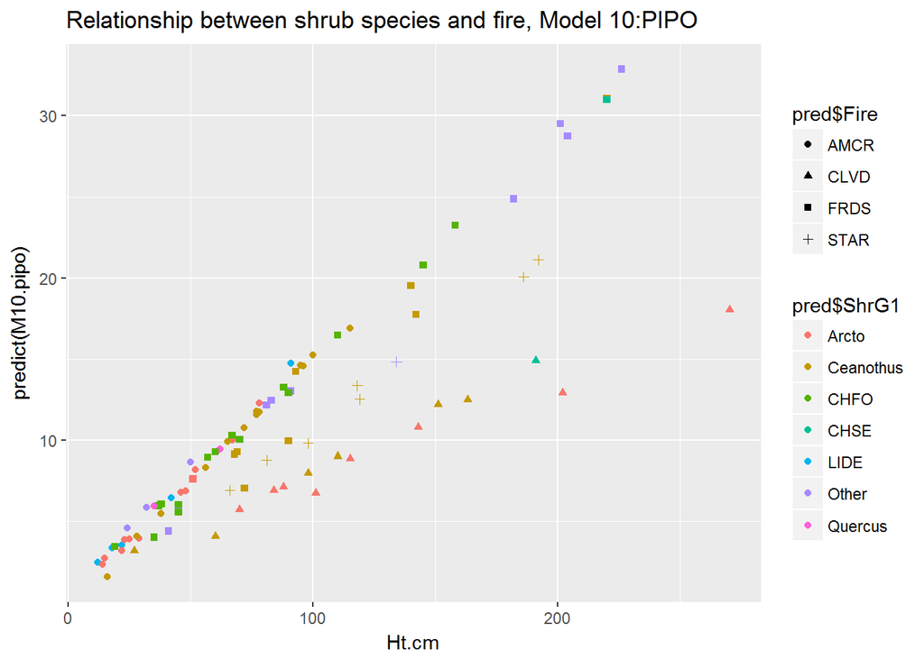

```r
ggplot(pred)+
  geom_point(aes(y=predict(M10.pipo),x=Ht.cm,col=pred$ShrG1, shape=pred$Fire))+
  labs(title = "Relationship between shrub species and fire, Model 10:PIPO")
```

- It appears there is a relationship but the shrub species in the flatter-sloped fires are also in other fires
- Potential conclusions from comparing abco and pipo results
  - basal diameter matters for ABCO but not for PIPO
  - shrub cover almost matters for PIPO but not for ABCO
- Try to refine further by using different cover segments and height segments and
- Then with all Pinus